# Risk Factor Analysis

## Outcome Variable

**Outcome Variable:** wasted

## Predictor Variables

**Intervention Variable:** perdiar6

**Adjustment Set:**

- arm
- sex
- W_mage
- meducyrs
- W_mhtcm
- W_mwtkg
- W_mbmi
- W_birthwt
- W_birthlen
- W_nrooms
- month
- brthmon
- impfloor
- impsan
- safeh20
- delta_W_mage
- delta_meducyrs
- delta_W_mhtcm
- delta_W_mwtkg
- delta_W_mbmi
- delta_W_birthwt
- delta_W_birthlen
- delta_W_nrooms
- delta_month
- delta_brthmon
- delta_impfloor
- delta_impsan
- delta_safeh20

## Stratifying Variables

The analysis was stratified on these variable(s):

- agecat
- studyid
- country

## Data Summary

| agecat | studyid | country | perdiar6 | wasted | n_cell | n |
| --- | --- | --- | --- | --- | --- | --- |
| Birth | ki0047075b-MAL-ED | BANGLADESH | (0%, 5%] | 0 | 75 | 241 |
| Birth | ki0047075b-MAL-ED | BANGLADESH | (0%, 5%] | 1 | 17 | 241 |
| Birth | ki0047075b-MAL-ED | BANGLADESH | 0% | 0 | 68 | 241 |
| Birth | ki0047075b-MAL-ED | BANGLADESH | 0% | 1 | 11 | 241 |
| Birth | ki0047075b-MAL-ED | BANGLADESH | >5% | 0 | 58 | 241 |
| Birth | ki0047075b-MAL-ED | BANGLADESH | >5% | 1 | 12 | 241 |
| Birth | ki0047075b-MAL-ED | BRAZIL | (0%, 5%] | 0 | 11 | 183 |
| Birth | ki0047075b-MAL-ED | BRAZIL | (0%, 5%] | 1 | 1 | 183 |
| Birth | ki0047075b-MAL-ED | BRAZIL | 0% | 0 | 164 | 183 |
| Birth | ki0047075b-MAL-ED | BRAZIL | 0% | 1 | 5 | 183 |
| Birth | ki0047075b-MAL-ED | BRAZIL | >5% | 0 | 2 | 183 |
| Birth | ki0047075b-MAL-ED | BRAZIL | >5% | 1 | 0 | 183 |
| Birth | ki0047075b-MAL-ED | INDIA | (0%, 5%] | 0 | 91 | 203 |
| Birth | ki0047075b-MAL-ED | INDIA | (0%, 5%] | 1 | 16 | 203 |
| Birth | ki0047075b-MAL-ED | INDIA | 0% | 0 | 39 | 203 |
| Birth | ki0047075b-MAL-ED | INDIA | 0% | 1 | 7 | 203 |
| Birth | ki0047075b-MAL-ED | INDIA | >5% | 0 | 40 | 203 |
| Birth | ki0047075b-MAL-ED | INDIA | >5% | 1 | 10 | 203 |
| Birth | ki0047075b-MAL-ED | NEPAL | (0%, 5%] | 0 | 51 | 168 |
| Birth | ki0047075b-MAL-ED | NEPAL | (0%, 5%] | 1 | 6 | 168 |
| Birth | ki0047075b-MAL-ED | NEPAL | 0% | 0 | 48 | 168 |
| Birth | ki0047075b-MAL-ED | NEPAL | 0% | 1 | 8 | 168 |
| Birth | ki0047075b-MAL-ED | NEPAL | >5% | 0 | 49 | 168 |
| Birth | ki0047075b-MAL-ED | NEPAL | >5% | 1 | 6 | 168 |
| Birth | ki0047075b-MAL-ED | PERU | (0%, 5%] | 0 | 83 | 279 |
| Birth | ki0047075b-MAL-ED | PERU | (0%, 5%] | 1 | 1 | 279 |
| Birth | ki0047075b-MAL-ED | PERU | 0% | 0 | 82 | 279 |
| Birth | ki0047075b-MAL-ED | PERU | 0% | 1 | 0 | 279 |
| Birth | ki0047075b-MAL-ED | PERU | >5% | 0 | 108 | 279 |
| Birth | ki0047075b-MAL-ED | PERU | >5% | 1 | 5 | 279 |

[output cut: 234 more lines]

The following strata were considered:

- agecat: 24 months, studyid: ki0047075b-MAL-ED, country: BANGLADESH
- agecat: 24 months, studyid: ki0047075b-MAL-ED, country: BRAZIL
- agecat: 24 months, studyid: ki0047075b-MAL-ED, country: INDIA
- agecat: 24 months, studyid: ki0047075b-MAL-ED, country: NEPAL
- agecat: 24 months, studyid: ki0047075b-MAL-ED, country: PERU
- agecat: 24 months, studyid: ki0047075b-MAL-ED, country: SOUTH AFRICA
- agecat: 24 months, studyid: ki0047075b-MAL-ED, country: TANZANIA, UNITED REPUBLIC OF
- agecat: 24 months, studyid: ki1017093-NIH-Birth, country: BANGLADESH
- agecat: 24 months, studyid: ki1017093b-PROVIDE, country: BANGLADESH
- agecat: 24 months, studyid: ki1017093c-NIH-Crypto, country: BANGLADESH
- agecat: 24 months, studyid: ki1114097-CMIN, country: BANGLADESH
- agecat: 24 months, studyid: ki1114097-CMIN, country: GUINEA-BISSAU
- agecat: 24 months, studyid: ki1114097-CMIN, country: PERU
- agecat: 24 months, studyid: ki1114097-CONTENT, country: PERU
- agecat: 6 months, studyid: ki0047075b-MAL-ED, country: BANGLADESH
- agecat: 6 months, studyid: ki0047075b-MAL-ED, country: BRAZIL
- agecat: 6 months, studyid: ki0047075b-MAL-ED, country: INDIA
- agecat: 6 months, studyid: ki0047075b-MAL-ED, country: NEPAL
- agecat: 6 months, studyid: ki0047075b-MAL-ED, country: PERU
- agecat: 6 months, studyid: ki0047075b-MAL-ED, country: SOUTH AFRICA
- agecat: 6 months, studyid: ki0047075b-MAL-ED, country: TANZANIA, UNITED REPUBLIC OF
- agecat: 6 months, studyid: ki1000109-ResPak, country: PAKISTAN
- agecat: 6 months, studyid: ki1017093-NIH-Birth, country: BANGLADESH
- agecat: 6 months, studyid: ki1017093b-PROVIDE, country: BANGLADESH
- agecat: 6 months, studyid: ki1017093c-NIH-Crypto, country: BANGLADESH
- agecat: 6 months, studyid: ki1114097-CMIN, country: BANGLADESH
- agecat: 6 months, studyid: ki1114097-CMIN, country: BRAZIL
- agecat: 6 months, studyid: ki1114097-CMIN, country: GUINEA-BISSAU
- agecat: 6 months, studyid: ki1114097-CMIN, country: PERU
- agecat: 6 months, studyid: ki1114097-CONTENT, country: PERU
- agecat: Birth, studyid: ki0047075b-MAL-ED, country: BANGLADESH
- agecat: Birth, studyid: ki0047075b-MAL-ED, country: BRAZIL
- agecat: Birth, studyid: ki0047075b-MAL-ED, country: INDIA
- agecat: Birth, studyid: ki0047075b-MAL-ED, country: NEPAL
- agecat: Birth, studyid: ki0047075b-MAL-ED, country: PERU
- agecat: Birth, studyid: ki0047075b-MAL-ED, country: SOUTH AFRICA
- agecat: Birth, studyid: ki0047075b-MAL-ED, country: TANZANIA, UNITED REPUBLIC OF
- agecat: Birth, studyid: ki1000109-ResPak, country: PAKISTAN
- agecat: Birth, studyid: ki1017093-NIH-Birth, country: BANGLADESH
- agecat: Birth, studyid: ki1017093c-NIH-Crypto, country: BANGLADESH
- agecat: Birth, studyid: ki1114097-CMIN, country: BANGLADESH
- agecat: Birth, studyid: ki1114097-CMIN, country: BRAZIL
- agecat: Birth, studyid: ki1114097-CMIN, country: PERU
- agecat: Birth, studyid: ki1114097-CONTENT, country: PERU

### Dropped Strata

Some strata were dropped due to rare outcomes:

- agecat: Birth, studyid: ki0047075b-MAL-ED, country: BRAZIL
- agecat: Birth, studyid: ki0047075b-MAL-ED, country: PERU
- agecat: Birth, studyid: ki0047075b-MAL-ED, country: SOUTH AFRICA
- agecat: Birth, studyid: ki0047075b-MAL-ED, country: TANZANIA, UNITED REPUBLIC OF
- agecat: Birth, studyid: ki1000109-ResPak, country: PAKISTAN
- agecat: Birth, studyid: ki1017093-NIH-Birth, country: BANGLADESH
- agecat: Birth, studyid: ki1017093c-NIH-Crypto, country: BANGLADESH
- agecat: Birth, studyid: ki1114097-CMIN, country: BANGLADESH
- agecat: Birth, studyid: ki1114097-CMIN, country: BRAZIL
- agecat: Birth, studyid: ki1114097-CMIN, country: PERU
- agecat: Birth, studyid: ki1114097-CONTENT, country: PERU
- agecat: 6 months, studyid: ki0047075b-MAL-ED, country: BANGLADESH
- agecat: 6 months, studyid: ki0047075b-MAL-ED, country: BRAZIL
- agecat: 6 months, studyid: ki0047075b-MAL-ED, country: INDIA
- agecat: 6 months, studyid: ki0047075b-MAL-ED, country: NEPAL
- agecat: 6 months, studyid: ki0047075b-MAL-ED, country: PERU
- agecat: 6 months, studyid: ki0047075b-MAL-ED, country: SOUTH AFRICA
- agecat: 6 months, studyid: ki0047075b-MAL-ED, country: TANZANIA, UNITED REPUBLIC OF
- agecat: 6 months, studyid: ki1017093c-NIH-Crypto, country: BANGLADESH
- agecat: 6 months, studyid: ki1114097-CMIN, country: BANGLADESH
- agecat: 6 months, studyid: ki1114097-CMIN, country: BRAZIL
- agecat: 6 months, studyid: ki1114097-CMIN, country: PERU
- agecat: 6 months, studyid: ki1114097-CONTENT, country: PERU
- agecat: 24 months, studyid: ki0047075b-MAL-ED, country: BRAZIL
- agecat: 24 months, studyid: ki0047075b-MAL-ED, country: NEPAL
- agecat: 24 months, studyid: ki0047075b-MAL-ED, country: PERU
- agecat: 24 months, studyid: ki0047075b-MAL-ED, country: SOUTH AFRICA
- agecat: 24 months, studyid: ki0047075b-MAL-ED, country: TANZANIA, UNITED REPUBLIC OF
- agecat: 24 months, studyid: ki1114097-CMIN, country: BANGLADESH
- agecat: 24 months, studyid: ki1114097-CMIN, country: GUINEA-BISSAU
- agecat: 24 months, studyid: ki1114097-CMIN, country: PERU
- agecat: 24 months, studyid: ki1114097-CONTENT, country: PERU

## Methods Detail

We’re interested in the causal parameters $E[Y_a]$ for all values of $a \in \mathcal{A}$. These parameters represent the mean outcome if, possibly contrary to fact, we intervened to set all units to have $A=a$. Under the randomization and positivity assumptions, these are identified by the statistical parameters $\psi_a=E_W[E_{Y|A,W}(Y|A=a,W)]$. In addition, we’re interested in the mean of $Y$, $E[Y]$ under no intervention (the observed mean). We will estimate these parameters by using SuperLearner to fit the relevant likelihood factors – $E_{Y|A,W}(Y|A=a,W)$ and $p(A=a|W)$, and then updating our likelihood fit using a joint TMLE.

For unadjusted analyses ($W=\{\}$), initial likelihoods were estimated using Lrnr_glm to estimate the simple $E(Y|A)$ and Lrnr_mean to estimate $p(A)$. For adjusted analyses, a small library containing Lrnr_glmnet, Lrnr_xgboost, and Lrnr_mean was used.

Having estimated these parameters, we will then use the delta method to estimate relative risks and attributable risks relative to a prespecified baseline level of $A$.

# Results Detail

## Results Plots

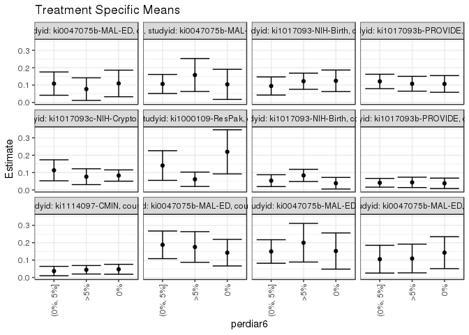

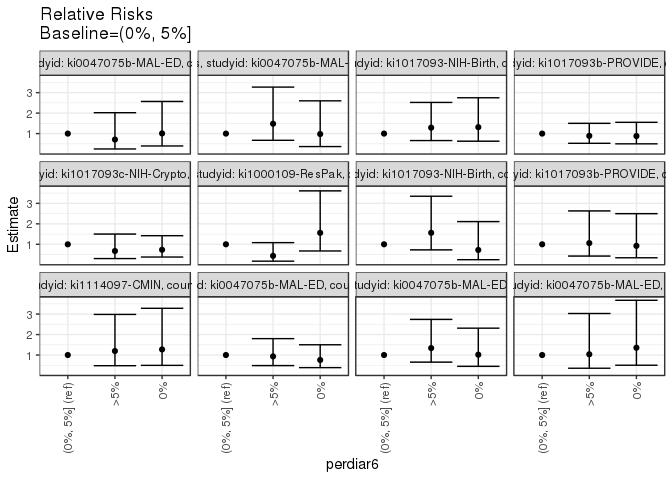

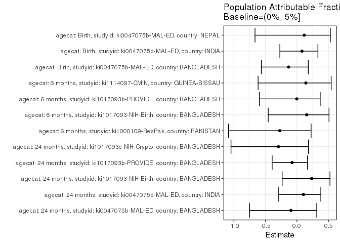

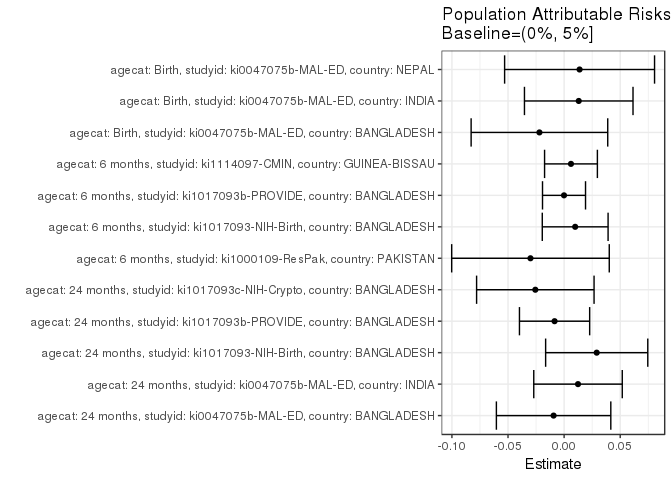

## Results Table

### Parameter: TSM

| agecat | studyid | country | intervention_level | baseline_level | estimate | ci_lower | ci_upper |
| --- | --- | --- | --- | --- | --- | --- | --- |
| Birth | ki0047075b-MAL-ED | BANGLADESH | (0%, 5%] | NA | 0.1879786 | 0.1085563 | 0.2674008 |
| Birth | ki0047075b-MAL-ED | BANGLADESH | 0% | NA | 0.1426751 | 0.0662626 | 0.2190877 |
| Birth | ki0047075b-MAL-ED | BANGLADESH | >5% | NA | 0.1754806 | 0.0871117 | 0.2638495 |
| Birth | ki0047075b-MAL-ED | INDIA | (0%, 5%] | NA | 0.1495327 | 0.0817958 | 0.2172696 |
| Birth | ki0047075b-MAL-ED | INDIA | 0% | NA | 0.1521739 | 0.0481184 | 0.2562294 |
| Birth | ki0047075b-MAL-ED | INDIA | >5% | NA | 0.2000000 | 0.0888536 | 0.3111464 |
| Birth | ki0047075b-MAL-ED | NEPAL | (0%, 5%] | NA | 0.1052632 | 0.0253547 | 0.1851716 |
| Birth | ki0047075b-MAL-ED | NEPAL | 0% | NA | 0.1428571 | 0.0509333 | 0.2347810 |
| Birth | ki0047075b-MAL-ED | NEPAL | >5% | NA | 0.1090909 | 0.0264540 | 0.1917278 |
| 6 months | ki1000109-ResPak | PAKISTAN | (0%, 5%] | NA | 0.1406250 | 0.0552744 | 0.2259756 |
| 6 months | ki1000109-ResPak | PAKISTAN | 0% | NA | 0.2195122 | 0.0925441 | 0.3464803 |
| 6 months | ki1000109-ResPak | PAKISTAN | >5% | NA | 0.0615385 | 0.0201400 | 0.1029369 |
| 6 months | ki1017093-NIH-Birth | BANGLADESH | (0%, 5%] | NA | 0.0535714 | 0.0194907 | 0.0876522 |
| 6 months | ki1017093-NIH-Birth | BANGLADESH | 0% | NA | 0.0387597 | 0.0054198 | 0.0720996 |
| 6 months | ki1017093-NIH-Birth | BANGLADESH | >5% | NA | 0.0836820 | 0.0485427 | 0.1188214 |
| 6 months | ki1017093b-PROVIDE | BANGLADESH | (0%, 5%] | NA | 0.0413223 | 0.0162241 | 0.0664205 |
| 6 months | ki1017093b-PROVIDE | BANGLADESH | 0% | NA | 0.0382166 | 0.0082017 | 0.0682314 |
| 6 months | ki1017093b-PROVIDE | BANGLADESH | >5% | NA | 0.0437158 | 0.0140669 | 0.0733648 |
| 6 months | ki1114097-CMIN | GUINEA-BISSAU | (0%, 5%] | NA | 0.0370370 | 0.0100929 | 0.0639811 |
| 6 months | ki1114097-CMIN | GUINEA-BISSAU | 0% | NA | 0.0471698 | 0.0186108 | 0.0757288 |
| 6 months | ki1114097-CMIN | GUINEA-BISSAU | >5% | NA | 0.0442804 | 0.0197696 | 0.0687913 |
| 24 months | ki0047075b-MAL-ED | BANGLADESH | (0%, 5%] | NA | 0.1084337 | 0.0413844 | 0.1754831 |
| 24 months | ki0047075b-MAL-ED | BANGLADESH | 0% | NA | 0.1093750 | 0.0327287 | 0.1860213 |
| 24 months | ki0047075b-MAL-ED | BANGLADESH | >5% | NA | 0.0769231 | 0.0119901 | 0.1418561 |
| 24 months | ki0047075b-MAL-ED | INDIA | (0%, 5%] | NA | 0.1065574 | 0.0516852 | 0.1614295 |
| 24 months | ki0047075b-MAL-ED | INDIA | 0% | NA | 0.1041667 | 0.0175574 | 0.1907759 |
| 24 months | ki0047075b-MAL-ED | INDIA | >5% | NA | 0.1578947 | 0.0630231 | 0.2527664 |
| 24 months | ki1017093-NIH-Birth | BANGLADESH | (0%, 5%] | NA | 0.0947858 | 0.0425729 | 0.1469988 |
| 24 months | ki1017093-NIH-Birth | BANGLADESH | 0% | NA | 0.1245714 | 0.0625056 | 0.1866372 |
| 24 months | ki1017093-NIH-Birth | BANGLADESH | >5% | NA | 0.1222086 | 0.0756862 | 0.1687310 |
| 24 months | ki1017093b-PROVIDE | BANGLADESH | (0%, 5%] | NA | 0.1209745 | 0.0796860 | 0.1622630 |
| 24 months | ki1017093b-PROVIDE | BANGLADESH | 0% | NA | 0.1065935 | 0.0585525 | 0.1546344 |
| 24 months | ki1017093b-PROVIDE | BANGLADESH | >5% | NA | 0.1075817 | 0.0649196 | 0.1502438 |
| 24 months | ki1017093c-NIH-Crypto | BANGLADESH | (0%, 5%] | NA | 0.1132075 | 0.0528312 | 0.1735839 |
| 24 months | ki1017093c-NIH-Crypto | BANGLADESH | 0% | NA | 0.0830325 | 0.0505064 | 0.1155586 |
| 24 months | ki1017093c-NIH-Crypto | BANGLADESH | >5% | NA | 0.0763359 | 0.0308207 | 0.1218511 |

### Parameter: E(Y)

| agecat | studyid | country | intervention_level | baseline_level | estimate | ci_lower | ci_upper |
| --- | --- | --- | --- | --- | --- | --- | --- |
| Birth | ki0047075b-MAL-ED | BANGLADESH | NA | NA | 0.1659751 | 0.1189041 | 0.2130461 |
| Birth | ki0047075b-MAL-ED | INDIA | NA | NA | 0.1625616 | 0.1116803 | 0.2134428 |
| Birth | ki0047075b-MAL-ED | NEPAL | NA | NA | 0.1190476 | 0.0699312 | 0.1681640 |
| 6 months | ki1000109-ResPak | PAKISTAN | NA | NA | 0.1106383 | 0.0704470 | 0.1508296 |
| 6 months | ki1017093-NIH-Birth | BANGLADESH | NA | NA | 0.0634328 | 0.0427791 | 0.0840865 |
| 6 months | ki1017093b-PROVIDE | BANGLADESH | NA | NA | 0.0412371 | 0.0250690 | 0.0574052 |
| 6 months | ki1114097-CMIN | GUINEA-BISSAU | NA | NA | 0.0431548 | 0.0277795 | 0.0585300 |
| 24 months | ki0047075b-MAL-ED | BANGLADESH | NA | NA | 0.0990566 | 0.0587480 | 0.1393652 |
| 24 months | ki0047075b-MAL-ED | INDIA | NA | NA | 0.1189427 | 0.0767376 | 0.1611478 |
| 24 months | ki1017093-NIH-Birth | BANGLADESH | NA | NA | 0.1238318 | 0.0925894 | 0.1550741 |
| 24 months | ki1017093b-PROVIDE | BANGLADESH | NA | NA | 0.1124567 | 0.0866788 | 0.1382347 |
| 24 months | ki1017093c-NIH-Crypto | BANGLADESH | NA | NA | 0.0875486 | 0.0630907 | 0.1120065 |

### Parameter: RR

| agecat | studyid | country | intervention_level | baseline_level | estimate | ci_lower | ci_upper |
| --- | --- | --- | --- | --- | --- | --- | --- |
| Birth | ki0047075b-MAL-ED | BANGLADESH | (0%, 5%] | (0%, 5%] | 1.0000000 | 1.0000000 | 1.000000 |
| Birth | ki0047075b-MAL-ED | BANGLADESH | 0% | (0%, 5%] | 0.7589969 | 0.3836954 | 1.501390 |
| Birth | ki0047075b-MAL-ED | BANGLADESH | >5% | (0%, 5%] | 0.9335138 | 0.4837683 | 1.801375 |
| Birth | ki0047075b-MAL-ED | INDIA | (0%, 5%] | (0%, 5%] | 1.0000000 | 1.0000000 | 1.000000 |
| Birth | ki0047075b-MAL-ED | INDIA | 0% | (0%, 5%] | 1.0176630 | 0.4481089 | 2.311130 |
| Birth | ki0047075b-MAL-ED | INDIA | >5% | (0%, 5%] | 1.3375000 | 0.6530101 | 2.739477 |
| Birth | ki0047075b-MAL-ED | NEPAL | (0%, 5%] | (0%, 5%] | 1.0000000 | 1.0000000 | 1.000000 |
| Birth | ki0047075b-MAL-ED | NEPAL | 0% | (0%, 5%] | 1.3571429 | 0.5016909 | 3.671258 |
| Birth | ki0047075b-MAL-ED | NEPAL | >5% | (0%, 5%] | 1.0363636 | 0.3546209 | 3.028726 |
| 6 months | ki1000109-ResPak | PAKISTAN | (0%, 5%] | (0%, 5%] | 1.0000000 | 1.0000000 | 1.000000 |
| 6 months | ki1000109-ResPak | PAKISTAN | 0% | (0%, 5%] | 1.5609756 | 0.6749617 | 3.610049 |
| 6 months | ki1000109-ResPak | PAKISTAN | >5% | (0%, 5%] | 0.4376068 | 0.1768440 | 1.082874 |
| 6 months | ki1017093-NIH-Birth | BANGLADESH | (0%, 5%] | (0%, 5%] | 1.0000000 | 1.0000000 | 1.000000 |
| 6 months | ki1017093-NIH-Birth | BANGLADESH | 0% | (0%, 5%] | 0.7235144 | 0.2482051 | 2.109034 |
| 6 months | ki1017093-NIH-Birth | BANGLADESH | >5% | (0%, 5%] | 1.5620642 | 0.7288727 | 3.347696 |
| 6 months | ki1017093b-PROVIDE | BANGLADESH | (0%, 5%] | (0%, 5%] | 1.0000000 | 1.0000000 | 1.000000 |
| 6 months | ki1017093b-PROVIDE | BANGLADESH | 0% | (0%, 5%] | 0.9248408 | 0.3426730 | 2.496054 |
| 6 months | ki1017093b-PROVIDE | BANGLADESH | >5% | (0%, 5%] | 1.0579235 | 0.4256558 | 2.629360 |
| 6 months | ki1114097-CMIN | GUINEA-BISSAU | (0%, 5%] | (0%, 5%] | 1.0000000 | 1.0000000 | 1.000000 |
| 6 months | ki1114097-CMIN | GUINEA-BISSAU | 0% | (0%, 5%] | 1.2735849 | 0.4942872 | 3.281531 |
| 6 months | ki1114097-CMIN | GUINEA-BISSAU | >5% | (0%, 5%] | 1.1955720 | 0.4792604 | 2.982496 |
| 24 months | ki0047075b-MAL-ED | BANGLADESH | (0%, 5%] | (0%, 5%] | 1.0000000 | 1.0000000 | 1.000000 |
| 24 months | ki0047075b-MAL-ED | BANGLADESH | 0% | (0%, 5%] | 1.0086806 | 0.3961636 | 2.568223 |
| 24 months | ki0047075b-MAL-ED | BANGLADESH | >5% | (0%, 5%] | 0.7094017 | 0.2491477 | 2.019890 |
| 24 months | ki0047075b-MAL-ED | INDIA | (0%, 5%] | (0%, 5%] | 1.0000000 | 1.0000000 | 1.000000 |
| 24 months | ki0047075b-MAL-ED | INDIA | 0% | (0%, 5%] | 0.9775641 | 0.3676251 | 2.599473 |
| 24 months | ki0047075b-MAL-ED | INDIA | >5% | (0%, 5%] | 1.4817814 | 0.6716051 | 3.269296 |
| 24 months | ki1017093-NIH-Birth | BANGLADESH | (0%, 5%] | (0%, 5%] | 1.0000000 | 1.0000000 | 1.000000 |
| 24 months | ki1017093-NIH-Birth | BANGLADESH | 0% | (0%, 5%] | 1.3142404 | 0.6282892 | 2.749096 |
| 24 months | ki1017093-NIH-Birth | BANGLADESH | >5% | (0%, 5%] | 1.2893126 | 0.6593030 | 2.521340 |
| 24 months | ki1017093b-PROVIDE | BANGLADESH | (0%, 5%] | (0%, 5%] | 1.0000000 | 1.0000000 | 1.000000 |
| 24 months | ki1017093b-PROVIDE | BANGLADESH | 0% | (0%, 5%] | 0.8811235 | 0.5006141 | 1.550852 |
| 24 months | ki1017093b-PROVIDE | BANGLADESH | >5% | (0%, 5%] | 0.8892922 | 0.5270241 | 1.500578 |
| 24 months | ki1017093c-NIH-Crypto | BANGLADESH | (0%, 5%] | (0%, 5%] | 1.0000000 | 1.0000000 | 1.000000 |
| 24 months | ki1017093c-NIH-Crypto | BANGLADESH | 0% | (0%, 5%] | 0.7334537 | 0.3784317 | 1.421536 |
| 24 months | ki1017093c-NIH-Crypto | BANGLADESH | >5% | (0%, 5%] | 0.6743003 | 0.3029924 | 1.500634 |

### Parameter: PAR

| agecat | studyid | country | intervention_level | baseline_level | estimate | ci_lower | ci_upper |
| --- | --- | --- | --- | --- | --- | --- | --- |
| Birth | ki0047075b-MAL-ED | BANGLADESH | (0%, 5%] | NA | -0.0220035 | -0.0828820 | 0.0388751 |
| Birth | ki0047075b-MAL-ED | INDIA | (0%, 5%] | NA | 0.0130289 | -0.0353475 | 0.0614053 |
| Birth | ki0047075b-MAL-ED | NEPAL | (0%, 5%] | NA | 0.0137845 | -0.0530351 | 0.0806041 |
| 6 months | ki1000109-ResPak | PAKISTAN | (0%, 5%] | NA | -0.0299867 | -0.1002165 | 0.0402431 |
| 6 months | ki1017093-NIH-Birth | BANGLADESH | (0%, 5%] | NA | 0.0098614 | -0.0194638 | 0.0391867 |
| 6 months | ki1017093b-PROVIDE | BANGLADESH | (0%, 5%] | NA | -0.0000852 | -0.0192549 | 0.0190845 |
| 6 months | ki1114097-CMIN | GUINEA-BISSAU | (0%, 5%] | NA | 0.0061177 | -0.0174198 | 0.0296553 |
| 24 months | ki0047075b-MAL-ED | BANGLADESH | (0%, 5%] | NA | -0.0093771 | -0.0603697 | 0.0416155 |
| 24 months | ki0047075b-MAL-ED | INDIA | (0%, 5%] | NA | 0.0123854 | -0.0270580 | 0.0518287 |
| 24 months | ki1017093-NIH-Birth | BANGLADESH | (0%, 5%] | NA | 0.0290459 | -0.0164750 | 0.0745669 |
| 24 months | ki1017093b-PROVIDE | BANGLADESH | (0%, 5%] | NA | -0.0085178 | -0.0398062 | 0.0227707 |
| 24 months | ki1017093c-NIH-Crypto | BANGLADESH | (0%, 5%] | NA | -0.0256589 | -0.0780037 | 0.0266859 |

### Parameter: PAF

| agecat | studyid | country | intervention_level | baseline_level | estimate | ci_lower | ci_upper |
| --- | --- | --- | --- | --- | --- | --- | --- |
| Birth | ki0047075b-MAL-ED | BANGLADESH | (0%, 5%] | NA | -0.1325709 | -0.5648875 | 0.1803138 |
| Birth | ki0047075b-MAL-ED | INDIA | (0%, 5%] | NA | 0.0801473 | -0.2702778 | 0.3339024 |
| Birth | ki0047075b-MAL-ED | NEPAL | (0%, 5%] | NA | 0.1157895 | -0.6652478 | 0.5305033 |
| 6 months | ki1000109-ResPak | PAKISTAN | (0%, 5%] | NA | -0.2710337 | -1.0857266 | 0.2254370 |
| 6 months | ki1017093-NIH-Birth | BANGLADESH | (0%, 5%] | NA | 0.1554622 | -0.4557559 | 0.5100524 |
| 6 months | ki1017093b-PROVIDE | BANGLADESH | (0%, 5%] | NA | -0.0020661 | -0.5935592 | 0.3698781 |
| 6 months | ki1114097-CMIN | GUINEA-BISSAU | (0%, 5%] | NA | 0.1417625 | -0.6162692 | 0.5442766 |
| 24 months | ki0047075b-MAL-ED | BANGLADESH | (0%, 5%] | NA | -0.0946644 | -0.7501686 | 0.3153288 |
| 24 months | ki0047075b-MAL-ED | INDIA | (0%, 5%] | NA | 0.1041287 | -0.2949297 | 0.3802093 |
| 24 months | ki1017093-NIH-Birth | BANGLADESH | (0%, 5%] | NA | 0.2345596 | -0.2341831 | 0.5252738 |
| 24 months | ki1017093b-PROVIDE | BANGLADESH | (0%, 5%] | NA | -0.0757426 | -0.3931099 | 0.1693246 |
| 24 months | ki1017093c-NIH-Crypto | BANGLADESH | (0%, 5%] | NA | -0.2930818 | -1.0465109 | 0.1829702 |